# Earthquake Depth vs Magnitude — Covariance & Correlation in R

Faithwin

2026-03-09

A teaching exercise using R’s built-in quakes dataset to explore the relationship between earthquake depth and magnitude using covariance and correlation.

## Dataset

The quakes dataset contains observations of 1,000 seismic events near Fiji recorded by the Harvard LASA seismograph network. Each row captures:

# Variable Description

lat Latitude of earthquake epicentre long Longitude of earthquake epicentre depth Depth of earthquake (km) mag Richter magnitude stations Number of stations that detected the event

```
##      lat   long depth mag stations
## 1 -20.42 181.62   562 4.8       41
## 2 -20.62 181.03   650 4.2       15
## 3 -26.00 184.10    42 5.4       43
## 4 -17.97 181.66   626 4.1       19
## 5 -20.42 181.96   649 4.0       11
## 6 -19.68 184.31   195 4.0       12
```

## Visualisation

Using scatterplot

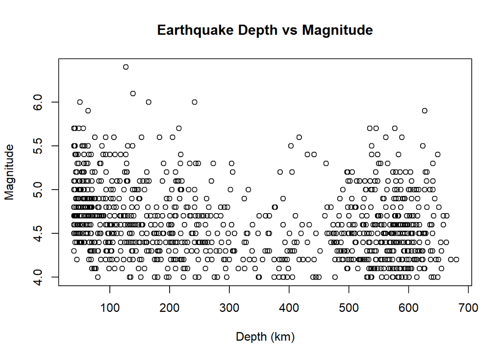

The plot shows a slight downward trend. This means the deeper earthquakes tend to have marginally lower surface magnitudes but with substantial scatter, hinting at a weak relationship.

We cannot decide using only the scatterplot. Therefore, we do a covariance check.

```
## [1] -20.02209
```

The negative sign confirms that depth and magnitude move in opposite directions: as depth increases, magnitude tends to decrease. However, the raw value of -20.02 is difficult to interpret in isolation because covariance retains the original units (km × Richter scale), making cross-variable comparisons unreliable. So, we run correlation instead.

```
## [1] -0.2306377
```

A value of −0.23 indicates a weak negative relationship. Depth explains only a small portion of the variation in magnitude — consistent with the scatter visible in the plot.Correlation standardises the covariance to a scale of −1 to +1, making it interpretable.

## Full correlation Matrix

```
##                   lat        long       depth         mag     stations
## lat       1.000000000 -0.36454404  0.03102583 -0.05046165 -0.002220645
## long     -0.364544037  1.00000000  0.14444341 -0.17306726 -0.053512460
## depth     0.031025831  0.14444341  1.00000000 -0.23063770 -0.073515097
## mag      -0.050461651 -0.17306726 -0.23063770  1.00000000  0.851182422
## stations -0.002220645 -0.05351246 -0.07351510  0.85118242  1.000000000
```

#Notable Findings mag ↔︎ stations = 0.85 — Strong positive correlation. More powerful earthquakes are detected by a greater number of stations, which makes physical sense: larger seismic events produce stronger signals that reach more sensors.

depth ↔︎ mag = −0.23 — Weak negative correlation. Deeper earthquakes tend to register slightly lower surface magnitudes.

lat ↔︎ long = −0.36 — Moderate negative correlation, reflecting geographic clustering of seismic activity in the Fiji–Tonga region.

depth ↔︎ stations = −0.07 — Near zero. Depth has almost no bearing on how many stations detect the event.

#Thank you.